# Modul 06: Analisis Regresi, Diagnostik Asumsi, & Seleksi Peubah

# 1 Pengantar Pemodelan Regresi dalam Ilmu Pertanian & Biologi

Apabila pada **Modul 05** kita mengukur keeratan hubungan yang bersifat simetris antara dua peubah melalui korelasi, maka pada **Modul 06** kita membangun **model persamaan matematis satu arah (*fungsional / kausalitas*)** untuk menduga atau menjelaskan keragaman **Peubah Tak Bebas / Respon ($Y$)** berdasarkan satu atau lebih **Peubah Bebas / Prediktor ($X_1, X_2, \dots, X_k$)**.

| Jenis Model & Metode di Modul 06 | Karakteristik Peubah $Y$ & $X$ | Fungsi Utama di R |
| --- | --- | --- |
| **1. Regresi Linier Sederhana (OLS)** | $Y$ kontinu, **1 peubah bebas** $X$ kontinu. | `lm(Y ~ X)` |
| **2. Regresi Linier Berganda (OLS & Matriks)** | $Y$ kontinu, **$k \ge 2$ peubah bebas** $X_1, \dots, X_k$ bebas multikolinieritas. | `lm(Y ~ X1 + X2)` & `solve(t(X) %*% X)` |
| **3. Regresi Logistik Biner** | **$Y$ kategorik biner (`0` / `1`)**, $X$ kontinu/kategorik. | `glm(Y ~ X, family = binomial)` |
| **4. Diagnostik Asumsi Sisaan & Ragam** | Pemeriksaan kenormalan galat dan kehomogenan ragam. | `lillie.test()`, `pearson.test()`, `bartlett.test()` |
| **5. Seleksi Peubah & Regresi Berbias** | Mengatasi **multikolinieritas serius ($\text{VIF} > 10$)** atau menyaring prediktor terbaik. | `car::vif()`, `step()`, `lm.ridge()`, `cv.glmnet()`, `pcr()`, `plsr()` |

# 2 Analisis 6.1: Regresi Linier Sederhana (OLS, Uji $F$, Uji-$t$ Dua Arah & Satu Arah, $R^2$, Root MSE)

## 2.1 Penjelasan Awal (Konsep Dasar)

**Konsep Dasar — Metode Kuadrat Terkecil (*Ordinary Least Squares* / OLS):**

**Regresi Linier Sederhana** mencari satu garis lurus terbaik $\hat{Y}_i = b_0 + b_1 X_i$ yang melintasi gugus titik pengamatan sedemikian rupa sehingga **jumlah kuadrat jarak vertikal (sisaan $e_i = Y_i - \hat{Y}_i$) bernilai paling minimum**:
$$\min_{b_0, b_1} \sum_{i=1}^n e_i^2 = \min_{b_0, b_1} \sum_{i=1}^n (Y_i - b_0 - b_1 X_i)^2$$
* **Intersep ($b_0$)**: Nilai dugaan rata-rata $Y$ ketika $X = 0$ (bermakna praktis hanya jika $X = 0$ berada di sekitar rentang pengamatan). * **Kemiringan / *Slope* ($b_1$)**: Besarnya perubahan rata-rata pada $Y$ untuk setiap kenaikan **1 satuan** pada $X$.

## 2.2 Konteks Kasus & Kapan Menggunakan Analisis Ini

**Studi Kasus: Kurva Kalibrasi Residu Herbisida Atrazine:**

- **Kapan Digunakan?** Gunakan **Regresi Linier Sederhana** ketika terdapat **satu peubah prediktor kuantitatif ($X$)** yang memengaruhi **satu peubah respon kontinu ($Y$)** secara linier, baik untuk mengukur besarnya laju perubahan $b_1$ maupun untuk memprediksi nilai $Y$ pada nilai $X$ tertentu.
- **Skenario Penelitian**: Di laboratorium kimia pertanian, peneliti membangun kurva baku kromatografi untuk menduga **Relative Peak Area ($Y$)** berdasarkan **Konsentrasi standar herbisida Atrazine ($X$, dalam ppm)** pada $n = 8$ titik konsentrasi (`0.50` hingga `20.00` ppm). Selain uji dua arah standar, peneliti juga ingin menguji hipotesis satu arah kanan ($H_1: \beta_1 > 0$). Dataset tersimpan pada `data/12_atrazine_regresi_sederhana.csv`.

## 2.3 Model Regresi, Rumus Penduga OLS, & Hipotesis

Model regresi linier sederhana populasi dan persamaan dugaannya:

$$Y_i = \beta_0 + \beta_1 X_i + \varepsilon_i, \quad \varepsilon_i \overset{\text{iid}}{\sim} N(0, \sigma^2) \qquad \implies \qquad \hat{Y}_i = b_0 + b_1 X_i$$

Rumus penduga OLS, Koefisien Determinasi ($R^2$), dan Simpangan Baku Sisaan (*Root MSE*):

$$b_1 = \frac{\sum_{i=1}^n (X_i - \bar{X})(Y_i - \bar{Y})}{\sum_{i=1}^n (X_i - \bar{X})^2}, \qquad b_0 = \bar{Y} - b_1 \bar{X}$$

$$R^2 = \frac{\text{JK}_{\text{Regresi}}}{\text{JK}_{\text{Total}}} = 1 - \frac{\text{JK}_{\text{Galat}}}{\text{JK}_{\text{Total}}}, \qquad \text{Root MSE} = s_{y \cdot x} = \sqrt{\text{KTG}} = \sqrt{\frac{\sum_{i=1}^n (Y_i - \hat{Y}_i)^2}{n - 2}}$$

**Pasangan Hipotesis Kemiringan Regresi ($\beta_1$):**

- **Uji Dua Arah**: $H_0 : \beta_1 = 0$ vs $H_1 : \beta_1 \neq 0$ ($X$ berpengaruh linier nyata terhadap $Y$).
- **Uji Satu Arah Kanan**: $H_0 : \beta_1 \le 0$ vs $H_1 : \beta_1 > 0$ (Peningkatan konsentrasi $X$ secara nyata **menaikkan** respon $Y$), menggunakan statistik $t_{\text{hitung}} = \frac{b_1}{\text{SE}(b_1)} \sim t_{(n - 2)}$.

## 2.4 Kode R Siap Pakai (Step-by-Step)

```r
# Langkah 1: Membaca data kalibrasi herbisida Atrazine
df_atrazine <- read.csv("../data/12_atrazine_regresi_sederhana.csv")
print(df_atrazine)
```

```
#>   Konsentrasi_X Peak_Area_Y
#> 1           0.5        1.42
#> 2           1.0        2.15
#> 3           2.0        3.55
#> 4           4.0        6.20
#> 5           8.0       11.85
#> 6          12.0       17.10
#> 7          16.0       22.45
#> 8          20.0       28.15
```

```r
# Langkah 2: Mengestimasi model OLS dengan lm() & menampilkan ringkasan lengkap + Tabel ANOVA
mod_slr <- lm(Peak_Area_Y ~ Konsentrasi_X, data = df_atrazine)
summary(mod_slr)
```

```
#>
#> Call:
#> lm(formula = Peak_Area_Y ~ Konsentrasi_X, data = df_atrazine)
#>
#> Residuals:
#>      Min       1Q   Median       3Q      Max
#> -0.15224 -0.04763 -0.01954  0.05133  0.15603
#>
#> Coefficients:
#>               Estimate Std. Error t value Pr(>|t|)
#> (Intercept)   0.785706   0.055569   14.14 7.82e-06 ***
#> Konsentrasi_X 1.363533   0.005283  258.12 2.28e-13 ***
#> ---
#> Signif. codes:  0 '***' 0.001 '**' 0.01 '*' 0.05 '.' 0.1 ' ' 1
#>
#> Residual standard error: 0.1031 on 6 degrees of freedom
#> Multiple R-squared:  0.9999, Adjusted R-squared:  0.9999
#> F-statistic: 6.663e+04 on 1 and 6 DF,  p-value: 2.282e-13
```

```r
anova(mod_slr)
```

```
#> Analysis of Variance Table
#>
#> Response: Peak_Area_Y
#>               Df Sum Sq Mean Sq F value    Pr(>F)
#> Konsentrasi_X  1 708.77  708.77   66625 2.282e-13 ***
#> Residuals      6   0.06    0.01
#> ---
#> Signif. codes:  0 '***' 0.001 '**' 0.01 '*' 0.05 '.' 0.1 ' ' 1
```

```r
# Langkah 3: Menghitung Uji-t Satu Arah untuk H0: beta1 <= 0 vs H1: beta1 > 0
t_hitung    <- coef(summary(mod_slr))["Konsentrasi_X", "t value"]
db_galat    <- df.residual(mod_slr)
p_satu_arah <- pt(t_hitung, df = db_galat, lower.tail = FALSE)
cat(sprintf("t_hitung = %.4f | db = %d | p-value 1 arah (H1: beta1 > 0) = %s\n",
            t_hitung, db_galat, format.pval(p_satu_arah)))
```

```
#> t_hitung = 258.1189 | db = 6 | p-value 1 arah (H1: beta1 > 0) = 1.1409e-13
```

```r
# Langkah 4: Selang Kepercayaan 95% bagi intersep beta0 dan kemiringan beta1
confint(mod_slr, level = 0.95)
```

```
#>                   2.5 %    97.5 %
#> (Intercept)   0.6497334 0.9216791
#> Konsentrasi_X 1.3506071 1.3764591
```

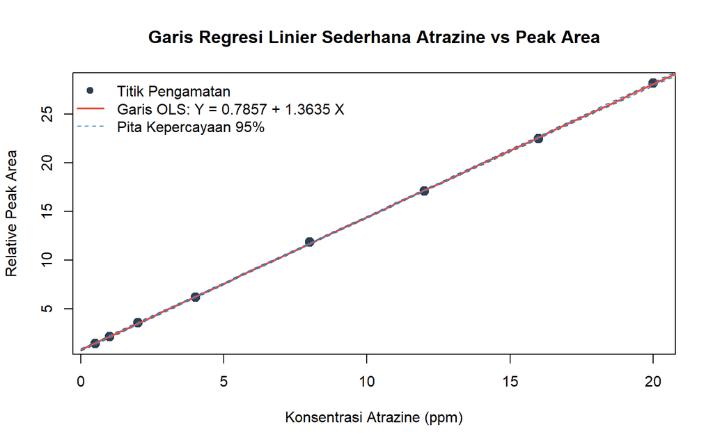

Figure 2.1: Garis regresi linier sederhana Konsentrasi Atrazine vs Relative Peak Area beserta pita kepercayaan 95%.

```r
# Langkah 5: Visualisasi Garis Regresi beserta Pita Kepercayaan 95%
x_baru  <- data.frame(Konsentrasi_X = seq(0, 21, length.out = 100))
pita_ci <- predict(mod_slr, newdata = x_baru, interval = "confidence", level = 0.95)

plot(df_atrazine$Konsentrasi_X, df_atrazine$Peak_Area_Y,
     pch = 19, col = "#2c3e50", cex = 1.4,
     xlab = "Konsentrasi Atrazine (ppm)", ylab = "Relative Peak Area",
     main = "Garis Regresi Linier Sederhana Atrazine vs Peak Area")
lines(x_baru$Konsentrasi_X, pita_ci[, "fit"], col = "#e74c3c", lwd = 2.2)
lines(x_baru$Konsentrasi_X, pita_ci[, "lwr"], col = "#2980b9", lty = 2)
lines(x_baru$Konsentrasi_X, pita_ci[, "upr"], col = "#2980b9", lty = 2)
legend("topleft", legend = c("Titik Pengamatan", "Garis OLS: Y = 0.7857 + 1.3635 X", "Pita Kepercayaan 95%"),
       pch = c(19, NA, NA), lty = c(NA, 1, 2), lwd = c(NA, 2.2, 1),
       col = c("#2c3e50", "#e74c3c", "#2980b9"), bty = "n")
```

## 2.5 Cara Membaca Output R & Kesimpulan Kasus

**Panduan Membaca Output `summary(mod_slr)` & `anova(mod_slr)`:**

1. **Persamaan Regresi Dugaan**: Dari kolom `Estimate` diperoleh **`b0 = 0.7857`** dan **`b1 = 1.3635`**, sehingga:
   $$\hat{Y} = 0,7857 + 1,3635 X$$
   Artinya, setiap peningkatan konsentrasi Atrazine sebesar **$1\text{ ppm}$** akan menaikkan rata-rata *Relative Peak Area* sebesar **$1,3635$ satuan** (dengan $\text{SK}_{95\%}: [1,3506;\; 1,3765]$).
2. **Uji-$t$ Dua Arah & Satu Arah serta Hubungannya dengan Uji $F$**:
   - Pada `Konsentrasi_X`, diperoleh **`t value = 258.12`** dengan nilai-$p$ dua arah **`2.28e-13 ***`** dan nilai-$p$ satu arah kanan separuhnya yaitu **`1.14e-13`** ($< 0,001$, Tolak $H_0$).
   - Perhatikan pada `anova(mod_slr)`: nilai **`F value = 66625`** sama persis dengan kuadrat dari $t_{\text{hitung}}$ ($258,1189^2 = 66625,37$)! Kesetaraan $F = t^2$ ini berlaku khusus pada regresi linier sederhana ($k = 1$).
3. **Ukuran Kebaikan Model (`Multiple R-squared` & `Residual standard error`)**:
   - **`Multiple R-squared = 0.9999`** ($99,99\%$): Sebesar $99,99\%$ keragaman *Relative Peak Area* mampu dijelaskan secara linier oleh variasi konsentrasi Atrazine!
   - **`Residual standard error = 0.1031`** ($\text{Root MSE} = \sqrt{0,0106} = 0,1031$ pada `6 degrees of freedom`): Simpangan baku melesetnya prediksi garis regresi sangat kecil, menandakan kurva kalibrasi sangat akurat.

**Kalimat Kesimpulan Siap Kutip:** > *“Berdasarkan analisis regresi linier sederhana, konsentrasi Atrazine berpengaruh positif sangat nyata terhadap Relative Peak Area ($t_{\text{hitung}} = 258,12$; $p\text{-value satu arah} = 1,14 \times 10^{-13} < 0,01$) dengan persamaan regresi $\hat{Y} = 0,7857 + 1,3635 X$, koefisien determinasi $R^2 = 99,99\%$, dan simpangan baku sisaan ($\text{Root MSE}$) sebesar $0,1031$.”*

# 3 Analisis 6.2: Regresi Linier Berganda & Pendugaan Matriks $\mathbf{b} = (\mathbf{X}'\mathbf{X})^{-1}\mathbf{X}'\mathbf{Y}$

## 3.1 Penjelasan Awal (Konsep Dasar)

**Konsep Dasar — Makna Koefisien Regresi Parsial & *Adjusted* $R^2$:**

Pada fenomena biologis dan pertanian nyata, hasil panen atau bobot ternak ($Y$) hampir selalu dipengaruhi oleh **banyak peubah bebas sekaligus** ($X_1, X_2, \dots, X_k$). Dalam **Regresi Linier Berganda**: * Koefisien $b_1$ disebut **koefisien regresi parsial**, yakni perubahan rata-rata $Y$ ketika $X_1$ naik 1 satuan **dengan asumsi peubah bebas lainnya ($X_2, \dots, X_k$) dijaga konstan (*ceteris paribus*)**. * Karena nilai $R^2$ biasa **pasti selalu naik** walaupun kita menambahkan peubah sampah yang tidak relevan, maka untuk menilai dan membandingkan model regresi berganda wajib digunakan **$R^2$ Terkoreksi (*Adjusted $R^2$*)** yang memberikan penalti terhadap penambahan jumlah parameter!

## 3.2 Konteks Kasus & Kapan Menggunakan Analisis Ini

**Studi Kasus: Pendugaan Matriks Regresi 10 Individu:**

- **Kapan Digunakan?** Gunakan **Regresi Linier Berganda OLS** ketika respon $Y$ kontinu dimodelkan oleh $k \ge 2$ prediktor dan tidak terjadi multikolinieritas parah antar-prediktor.
- **Skenario Kasus**: Mengamati $n = 10$ individu (`data/13_individu_regresi_berganda.csv`) dengan dua peubah prediktor utama $X_1$ dan $X_2$ terhadap respon $Y$, sekaligus membuktikan secara komputasi bahwa hasil fungsi `lm()` identik hingga desimal terakhir dengan rumus aljabar matriks $\mathbf{b} = (\mathbf{X}'\mathbf{X})^{-1}\mathbf{X}'\mathbf{Y}$!

## 3.3 Model Matriks Regresi Berganda & Hipotesis Simultan vs Parsial

Dalam notasi matriks untuk $n$ pengamatan dan $p = k + 1$ parameter (termasuk intersep):

$$\mathbf{Y}_{n \times 1} = \mathbf{X}_{n \times p}\boldsymbol{\beta}_{p \times 1} + \boldsymbol{\varepsilon}_{n \times 1}, \qquad \mathbf{b} = (\mathbf{X}'\mathbf{X})^{-1}\mathbf{X}'\mathbf{Y}, \qquad \widehat{\text{Cov}}(\mathbf{b}) = \text{KTG} \cdot (\mathbf{X}'\mathbf{X})^{-1}$$

Koefisien Determinasi Terkoreksi (*Adjusted* $R^2$):

$$R^2_{\text{adj}} = 1 - \frac{\text{JK}_{\text{Galat}} / (n - k - 1)}{\text{JK}_{\text{Total}} / (n - 1)} = 1 - \frac{\text{KTG}}{\text{KTT}}$$

**Dua Tahap Pengujian Hipotesis:**

1. **Uji $F$ Simultan (Kelayakan Model Bersama-sama)**:
   - $H_0 : \beta_1 = \beta_2 = \dots = \beta_k = 0$ (Seluruh peubah bebas secara bersama-sama tidak berpengaruh terhadap $Y$).
   - $H_1 :$ Minimal ada satu $\beta_j \neq 0$ ($j = 1, \dots, k$).
2. **Uji-$t$ Parsial (Kontribusi Masing-masing Prediktor)**:
   - $H_0 : \beta_j = 0$ vs $H_1 : \beta_j \neq 0$ (menguji pengaruh $X_j$ setelah memperhitungkan prediktor lainnya di dalam model).

## 3.4 Kode R Siap Pakai (Step-by-Step)

```r
# Langkah 1: Membaca dataset 10 individu regresi berganda
df_mlr <- read.csv("../data/13_individu_regresi_berganda.csv")
df_mlr[, c("Individu", "X1", "X2", "Y")]
```

```
#>    Individu X1 X2    Y
#> 1         1  2  3 27.5
#> 2         2  4  5 34.8
#> 3         3  5  4 35.1
#> 4         4  6  7 43.2
#> 5         5  8  6 44.0
#> 6         6  9  9 52.3
#> 7         7 10  8 51.8
#> 8         8 11 11 60.1
#> 9         9 13 10 61.5
#> 10       10 15 12 69.2
```

```r
# Langkah 2: Estimasi Regresi Linier Berganda menggunakan fungsi lm()
mod_mlr <- lm(Y ~ X1 + X2, data = df_mlr)
summary(mod_mlr)
```

```
#>
#> Call:
#> lm(formula = Y ~ X1 + X2, data = df_mlr)
#>
#> Residuals:
#>      Min       1Q   Median       3Q      Max
#> -0.37501 -0.13409  0.02858  0.07656  0.33292
#>
#> Coefficients:
#>             Estimate Std. Error t value Pr(>|t|)
#> (Intercept) 17.57705    0.23266   75.55 1.87e-11 ***
#> X1           1.72870    0.05986   28.88 1.54e-08 ***
#> X2           2.13663    0.08128   26.29 2.95e-08 ***
#> ---
#> Signif. codes:  0 '***' 0.001 '**' 0.01 '*' 0.05 '.' 0.1 ' ' 1
#>
#> Residual standard error: 0.2482 on 7 degrees of freedom
#> Multiple R-squared:  0.9997, Adjusted R-squared:  0.9997
#> F-statistic: 1.307e+04 on 2 and 7 DF,  p-value: 3.137e-13
```

```r
anova(mod_mlr)
```

```
#> Analysis of Variance Table
#>
#> Response: Y
#>           Df  Sum Sq Mean Sq  F value    Pr(>F)
#> X1         1 1567.95 1567.95 25455.36 1.003e-13 ***
#> X2         1   42.56   42.56   690.96 2.952e-08 ***
#> Residuals  7    0.43    0.06
#> ---
#> Signif. codes:  0 '***' 0.001 '**' 0.01 '*' 0.05 '.' 0.1 ' ' 1
```

```r
# Langkah 3: Pembuktian Aljabar Matriks OLS b = (X'X)^(-1) X'Y
X_mat   <- as.matrix(cbind(Intersep = 1, df_mlr[, c("X1", "X2")])) # Matriks desain 10 x 3
Y_vec   <- as.matrix(df_mlr$Y)                                     # Vektor respon 10 x 1

XtX     <- t(X_mat) %*% X_mat       # Matriks X'X berukuran 3 x 3
XtX_inv <- solve(XtX)               # Matriks kebalikan (X'X)^(-1)
XtY     <- t(X_mat) %*% Y_vec       # Vektor X'Y berukuran 3 x 1
b_mat   <- XtX_inv %*% XtY          # Vektor penduga OLS b

# Menghitung Galat Baku (Std. Error) dari akar elemen diagonal matriks KTG * (X'X)^(-1)
ktg_mlr <- sum((Y_vec - X_mat %*% b_mat)^2) / (nrow(X_mat) - ncol(X_mat))
se_mat  <- sqrt(diag(ktg_mlr * XtX_inv))

# Membandingkan hasil perhitungan matriks manual vs fungsi lm()
round(cbind(b_Matriks  = as.vector(b_mat),
            b_lm       = coef(mod_mlr),
            SE_Matriks = se_mat,
            SE_lm      = coef(summary(mod_mlr))[, "Std. Error"]), 5)
```

```
#>             b_Matriks     b_lm SE_Matriks   SE_lm
#> (Intercept)  17.57705 17.57705    0.23266 0.23266
#> X1            1.72870  1.72870    0.05986 0.05986
#> X2            2.13663  2.13663    0.08128 0.08128
```

## 3.5 Cara Membaca Output R & Kesimpulan Kasus

**Panduan Membaca Output `summary(mod_mlr)` & Aljabar Matriks:**

1. **Bukti Identitas Matriks**: Kolom `b_Matriks` dan `SE_Matriks` menghasilkan angka yang **100% identik** dengan `lm()`, yakni $\hat{Y} = 17,5771 + 1,7287 X_1 + 2,1366 X_2$.
2. **Uji $F$ Simultan (Baris paling bawah `summary`)**:
   - **`F-statistic: 1.307e+04 on 2 and 7 DF, p-value: 3.137e-13`** ($< 0,001$) $\rightarrow$ Tolak $H_0$ simultan: $X_1$ dan $X_2$ secara bersama-sama sangat nyata menjelaskan respon $Y$ dengan **`Adjusted R-squared = 0.9997`** ($99,97\%$).
3. **Uji-$t$ Parsial (Tabel `Coefficients`)**:
   - **`X1`**: `b1 = 1.7287`, `t value = 28.88`, `Pr(>|t|) = 1.54e-08 ***` $\rightarrow$ Jika $X_2$ konstan, kenaikan 1 satuan $X_1$ meningkatkan $Y$ sebesar $1,7287$ satuan.
   - **`X2`**: `b2 = 2.1366`, `t value = 26.29`, `Pr(>|t|) = 2.95e-08 ***` $\rightarrow$ Jika $X_1$ konstan, kenaikan 1 satuan $X_2$ meningkatkan $Y$ sebesar $2,1366$ satuan.

**Kalimat Kesimpulan Siap Kutip:** > *“Analisis regresi linier berganda menghasilkan persamaan dugaan $\hat{Y} = 17,5771 + 1,7287 X_1 + 2,1366 X_2$ yang layak secara simultan ($F_{\text{hitung}} = 13.070$; $p = 3,14 \times 10^{-13}$; $R^2_{\text{adj}} = 99,97\%$), di mana baik peubah $X_1$ ($t = 28,88$; $p = 1,54 \times 10^{-8}$) maupun $X_2$ ($t = 26,29$; $p = 2,95 \times 10^{-8}$) berpengaruh positif sangat nyata secara parsial terhadap respon $Y$.”*

# 4 Analisis 6.3: Regresi Logistik Biner (Untuk Respon $Y$ Kategorik Biner)

## 4.1 Penjelasan Awal (Konsep Dasar)

**Konsep Dasar — Mengapa Respon Biner (`0` dan `1`) Tidak Boleh Dianalisis dengan OLS `lm()`?**

Apabila respon penelitian berupa kejadian dikotomis/biner seperti **Mati (`1`) vs Hidup (`0`)** atau **Terserang Penyakit (`1`) vs Sehat (`0`)**, penggunaan regresi linier biasa `lm()` akan menghasilkan dugaan peluang yang **bisa tembus di bawah $0$ atau melebihi $1$** serta melanggar asumsi kehomogenan ragam!

**Regresi Logistik Biner** memodelkan logaritma dari rasio kecenderungan (**logit**) sehingga kurva dugaan peluang $\hat{\pi}(X) = P(Y = 1 \mid X)$ selalu berbentuk **huruf S (*sigmoid*) yang terikat rapi di antara $0$ dan $1$**.

## 4.2 Konteks Kasus & Kapan Menggunakan Analisis Ini

**Studi Kasus: *Bioassay* Toksikologi Pestisida Nabati:**

- **Kapan Digunakan?** Gunakan **Regresi Logistik Biner (`glm(..., family = binomial)` )** ketika peubah respon $Y$ hanya memiliki **dua kategori (`0` dan `1`)**.
- **Skenario Penelitian**: Pengujian toksisitas ekstrak pestisida nabati pada berbagai tingkat **Dosis ($X$, ml/L)** terhadap status **Kematian Serangga Hama ($Y$: `1` = Mati, `0` = Hidup)** pada $n = 15$ unit pengamatan untuk menduga besarnya *Odds Ratio* dan konsentrasi mematikan separuh populasi ($\text{LD}_{50}$).

## 4.3 Model Logit, Rumus Peluang Sigmoid, *Odds Ratio*, & Hipotesis

Misalkan $\pi(X) = P(Y = 1 \mid X)$ adalah peluang kematian hama pada dosis $X$. Transformasi logit dan fungsi peluang baliknya adalah:

$$\text{logit}[\pi(X)] = \ln\!\left(\frac{\pi(X)}{1 - \pi(X)}\right) = \beta_0 + \beta_1 X \quad \Longleftrightarrow \quad \pi(X) = \frac{e^{\beta_0 + \beta_1 X}}{1 + e^{\beta_0 + \beta_1 X}}$$

Ukuran interpretasi utama adalah **Rasio Kecenderungan (*Odds Ratio* / OR)** dan **Dosis Letal Tengah ($\text{LD}_{50}$, saat $\pi = 0,50 \implies \text{logit} = 0$)**:

$$\text{OR} = e^{\beta_1}, \qquad \widehat{\text{LD}}_{50} = -\frac{b_0}{b_1}$$

**Pasangan Hipotesis (Uji Wald $Z$ & Penurunan Devians):**

- $H_0 : \beta_1 = 0$ ($\text{OR} = 1$, dosis pestisida tidak memengaruhi peluang kematian serangga).
- $H_1 : \beta_1 \neq 0$ ($\text{OR} \neq 1$, dosis pestisida memengaruhi peluang kematian serangga).

## 4.4 Kode R Siap Pakai (Step-by-Step)

```r
# Langkah 1: Menyusun data bioassay Dosis Pestisida (ml/L) vs Kematian Biner (0/1)
df_log <- data.frame(
  Dosis_Pestisida = c(2, 4, 6, 8, 10, 12, 14, 16, 18, 20, 3, 5, 9, 13, 17),
  Mati_Biner      = c(0, 0, 0, 0,  1,  0,  1,  1,  1,  1, 0, 0, 1,  1,  1)
)

# Langkah 2: Mengestimasi Generalized Linear Model (GLM) keluarga Binomial Link Logit
mod_logistik <- glm(Mati_Biner ~ Dosis_Pestisida, data = df_log,
                    family = binomial(link = "logit"))
summary(mod_logistik)
```

```
#>
#> Call:
#> glm(formula = Mati_Biner ~ Dosis_Pestisida, family = binomial(link = "logit"),
#>     data = df_log)
#>
#> Coefficients:
#>                 Estimate Std. Error z value Pr(>|z|)
#> (Intercept)      -6.1321     3.2770  -1.871   0.0613 .
#> Dosis_Pestisida   0.6338     0.3269   1.939   0.0525 .
#> ---
#> Signif. codes:  0 '***' 0.001 '**' 0.01 '*' 0.05 '.' 0.1 ' ' 1
#>
#> (Dispersion parameter for binomial family taken to be 1)
#>
#>     Null deviance: 20.7277  on 14  degrees of freedom
#> Residual deviance:  7.8119  on 13  degrees of freedom
#> AIC: 11.812
#>
#> Number of Fisher Scoring iterations: 6
```

```r
# Uji Nisbah Kemungkinan (Likelihood Ratio Test) penurunan Devians model
anova(mod_logistik, test = "Chisq")
```

```
#> Analysis of Deviance Table
#>
#> Model: binomial, link: logit
#>
#> Response: Mati_Biner
#>
#> Terms added sequentially (first to last)
#>
#>
#>                 Df Deviance Resid. Df Resid. Dev  Pr(>Chi)
#> NULL                               14    20.7277
#> Dosis_Pestisida  1   12.916        13     7.8119 0.0003258 ***
#> ---
#> Signif. codes:  0 '***' 0.001 '**' 0.01 '*' 0.05 '.' 0.1 ' ' 1
```

```r
# Langkah 3: Menghitung Odds Ratio exp(b) dan titik Dosis Letal 50% (LD50)
round(exp(coef(mod_logistik)), 4)
```

```
#>     (Intercept) Dosis_Pestisida
#>          0.0022          1.8847
```

```r
ld50 <- -coef(mod_logistik)[1] / coef(mod_logistik)[2]
cat(sprintf("Dugaan LD50 = %.2f ml/L\n", ld50))
```

```
#> Dugaan LD50 = 9.68 ml/L
```

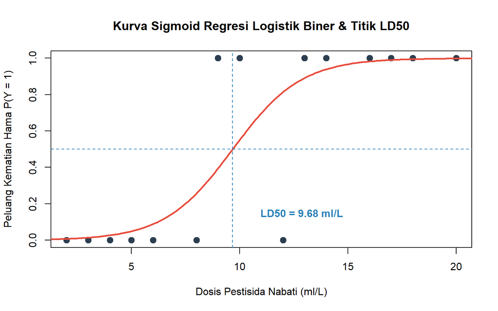

Figure 4.1: Kurva sigmoid peluang kematian serangga hasil Regresi Logistik Biner beserta titik penduga LD50.

```r
# Langkah 4: Visualisasi Kurva Sigmoid Peluang Kematian P(Y = 1 | X)
dosis_grid   <- seq(0, 22, length.out = 200)
peluang_duga <- predict(mod_logistik, newdata = data.frame(Dosis_Pestisida = dosis_grid),
                        type = "response")

plot(df_log$Dosis_Pestisida, df_log$Mati_Biner,
     pch = 19, col = "#2c3e50", cex = 1.3,
     xlab = "Dosis Pestisida Nabati (ml/L)", ylab = "Peluang Kematian Hama P(Y = 1)",
     main = "Kurva Sigmoid Regresi Logistik Biner & Titik LD50")
lines(dosis_grid, peluang_duga, col = "#e74c3c", lwd = 2.5)
abline(h = 0.50, v = ld50, col = "#2980b9", lty = 2)
text(ld50 + 3.2, 0.15, sprintf("LD50 = %.2f ml/L", ld50), col = "#2980b9", font = 2)
```

## 4.5 Cara Membaca Output R & Kesimpulan Kasus

**Panduan Membaca Output `glm(..., family = binomial)`:**

1. **Persamaan Logit & Penurunan Devians**:
   - Diperoleh $\text{logit}(\hat{\pi}) = -6,1321 + 0,6338 X$.
   - Penurunan devians dari `Null deviance = 20.728` menjadi `Residual deviance = 7.812` sebesar $\Delta G^2 = 12,916$ ($\text{db} = 1$) pada uji *Likelihood Ratio* (`anova(..., test = "Chisq")`) sangat nyata (`p = 0.000326 ***` — uji *Likelihood Ratio* lebih akurat pada ukuran sampel kecil daripada pendekatan asimtotik Wald `z = 1.939, p = 0.0525`).
2. **Interpretasi *Odds Ratio* (`exp(b1) = 1.8847`) & $\text{LD}_{50}$**:
   - Setiap peningkatan dosis pestisida sebesar **$1\text{ ml/L}$** melipatgandakan kecenderungan (*odds*) kematian serangga sebesar **`1.8847` kali lipat** (meningkat $88,47\%$).
   - Konsentrasi yang diperkirakan mematikan $50\%$ populasi serangga uji adalah **`LD50 = 9.68 ml/L`**.

**Kalimat Kesimpulan Siap Kutip:** > *“Berdasarkan pemodelan regresi logistik biner, peningkatan dosis pestisida nabati secara nyata meningkatkan peluang kematian serangga hama ($\Delta G^2 = 12,92$; $p = 0,00033$) dengan persamaan $\text{logit}(\hat{\pi}) = -6,1321 + 0,6338 X$ dan nilai Odds Ratio sebesar $1,8847$, serta estimasi konsentrasi $\text{LD}_{50}$ sebesar $9,68\text{ ml/L}$.”*

# 5 Analisis 6.4: Diagnostik Visual, Uji Normalitas Sisaan (Lilliefors & Khi-Kuadrat), & Uji Kehomogenan Ragam (Bartlett & $F_{\max}$ Hartley)

## 5.1 Penjelasan Awal (Konsep Dasar)

**Konsep Dasar — Memeriksa Keabsahan Asumsi Klasik Galat ($\varepsilon_i \overset{\text{iid}}{\sim} N(0, \sigma^2)$):**

Seluruh uji $F$ dan uji-$t$ pada ANOVA maupun Regresi berdiri di atas tiga tiang asumsi sisaan ($e_i = Y_i - \hat{Y}_i$): 1. **Pemeriksaan Visual (`boxplot` & Plot $e_i$ vs $\hat{Y}_i$)**: Memastikan tidak ada pencilan ekstrem dan titik-titik sisaan menyebar acak membentuk pita horizontal di sekitar nol (tidak membentuk **corong melebar = heteroskedastisitas** atau **parabola melengkung = salah spesifikasi model**). 2. **Asumsi Kenormalan Sisaan**: Diuji secara formal dengan **Uji Lilliefors** (perbaikan Kolmogorov-Smirnov ketika $\mu$ dan $\sigma^2$ diduga dari sampel) dan **Uji Khi-Kuadrat *Goodness-of-Fit* Pearson**. 3. **Asumsi Kehomogenan Ragam (*Homoscedasticity*)**: Pada data berkelompok/perlakuan, diuji dengan **Uji Bartlett** (berbasis logaritma ragam gabungan) dan **Uji $F_{\max}$ Hartley** (rasio ragam terbesar terhadap ragam terkecil).

## 5.2 Konteks Kasus & Kapan Menggunakan Analisis Ini

**Kriteria Keputusan Pengujian Asumsi:**

Berbeda dari uji pengaruh perlakuan/regresi di mana kita sering mengharapkan tolak $H_0$, **pada pengujian asumsi normalitas dan kehomogenan ragam, asumsi justru TERPENUHI apabila `p-value > 0.05` (Gagal Menolak $H_0$)**! Kita akan memeriksa kenormalan sisaan model regresi berganda (`mod_mlr`) serta kehomogenan ragam antar-perlakuan pada dataset *Red Clover* (`df_clover`).

## 5.3 Rumus Statistik Uji Normalitas & Kehomogenan Ragam + Hipotesis

1. **Uji Normalitas Lilliefors & Khi-Kuadrat**:
   - $H_0 :$ Sisaan menyebar mengikuti sebaran Normal $N(0, \sigma^2)$ vs $H_1 :$ Sisaan tidak menyebar Normal.
   - Statistik Lilliefors: $D = \max_i |F^*(z_i) - S_n(z_i)|$, dengan $z_i = (e_i - \bar{e})/s_e$.
2. **Uji Kehomogenan Ragam Bartlett & $F_{\max}$ Hartley**:
   - $H_0 : \sigma_1^2 = \sigma_2^2 = \dots = \sigma_t^2$ (Ragam galat antar-perlakuan homogen) vs $H_1 :$ minimal ada satu $\sigma_i^2$ yang berbeda.
   - Statistik **Uji $F_{\max}$ Hartley** (untuk ulangan sama $r$):
     $$F_{\max} = \frac{\max(s_1^2, s_2^2, \dots, s_t^2)}{\min(s_1^2, s_2^2, \dots, s_t^2)}$$

## 5.4 Kode R Siap Pakai (Step-by-Step)

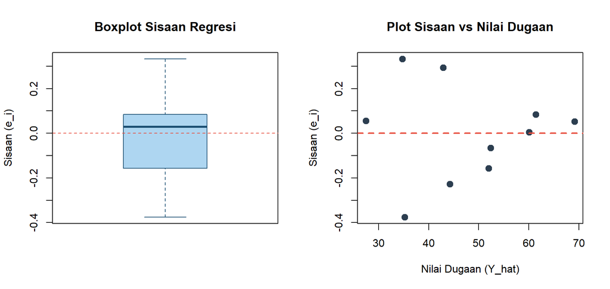

Figure 5.1: Diagnostik visual sisaan regresi berganda: Boxplot sisaan simetris tanpa pencilan (kiri) dan sebaran acak sisaan terhadap nilai dugaan (kanan).

```r
library(nortest)

# mengekstrak vektor sisaan (e_i) dan nilai dugaan (Y_hat) dari model regresi berganda
sisaan <- residuals(mod_mlr)
y_duga <- fitted(mod_mlr)

# Langkah 1: Diagnostik Visual Sisaan (Boxplot & Plot Sisaan vs Y_hat)
par(mfrow = c(1, 2))
boxplot(sisaan, col = "#aed6f1", border = "#1b4f72",
        main = "Boxplot Sisaan Regresi", ylab = "Sisaan (e_i)")
abline(h = 0, col = "#e74c3c", lty = 2)

plot(y_duga, sisaan, pch = 19, col = "#2c3e50", cex = 1.3,
     xlab = "Nilai Dugaan (Y_hat)", ylab = "Sisaan (e_i)",
     main = "Plot Sisaan vs Nilai Dugaan")
abline(h = 0, col = "#e74c3c", lty = 2, lwd = 2)
```

```r
par(mfrow = c(1, 1))

# Langkah 2: Uji Formal Kenormalan Sisaan (Lilliefors & Khi-Kuadrat Pearson)
lillie.test(sisaan)
```

```
#>
#>  Lilliefors (Kolmogorov-Smirnov) normality test
#>
#> data:  sisaan
#> D = 0.15138, p-value = 0.7433
```

```r
pearson.test(sisaan)
```

```
#>
#>  Pearson chi-square normality test
#>
#> data:  sisaan
#> P = 5.6, p-value = 0.1328
```

```r
# Langkah 3: Uji Formal Kehomogenan Ragam Antar-Perlakuan (Bartlett & F-Max Hartley)
df_clover <- read.csv("../data/02_red_clover_ral.csv")
df_clover$Perlakuan <- factor(df_clover$Perlakuan)

bartlett.test(Kadar_N ~ Perlakuan, data = df_clover)
```

```
#>
#>  Bartlett test of homogeneity of variances
#>
#> data:  Kadar_N by Perlakuan
#> Bartlett's K-squared = 0.13872, df = 5, p-value = 0.9996
```

```r
# Menghitung nilai statistik F-Max Hartley (s2_maksimum / s2_minimum)
ragam_per_grup <- tapply(df_clover$Kadar_N, df_clover$Perlakuan, var)
print(round(ragam_per_grup, 4))
```

```
#>    3DOK1   3DOK13    3DOK4    3DOK5    3DOK7 Komposit
#>     5.30     3.74     4.30     4.70     4.31     4.00
```

```r
F_max_hartley <- max(ragam_per_grup) / min(ragam_per_grup)
cat(sprintf("Nilai Statistik F-Max Hartley = %.4f / %.4f = %.4f\n",
            max(ragam_per_grup), min(ragam_per_grup), F_max_hartley))
```

```
#> Nilai Statistik F-Max Hartley = 5.3000 / 3.7400 = 1.4171
```

## 5.5 Cara Membaca Output R & Kesimpulan Kasus

**Panduan Membaca Hasil Diagnostik Asumsi:**

1. **Visual Sisaan**: Boxplot tampak simetris terhadap garis median mendekati nol tanpa titik pencilan di luar kumis (*whisker*), dan plot `sisaan vs y_duga` menyebar acak di atas dan bawah garis horizontal `0` tanpa pola corong ataupun pola lengkung.
2. **Uji Normalitas Sisaan**:
   - **Uji Lilliefors**: `D = 0.15138`, **`p-value = 0.7433 > 0.05`** $\rightarrow$ Gagal menolak $H_0$ (**Asumsi Normalitas Terpenuhi!**).
   - **Uji Khi-Kuadrat Pearson**: `P = 5.6`, **`p-value = 0.1328 > 0.05`** $\rightarrow$ Konsisten menyatakan **Asumsi Normalitas Terpenuhi**.
3. **Uji Kehomogenan Ragam**:
   - **Uji Bartlett**: `Bartlett's K-squared = 0.13872`, `df = 5`, **`p-value = 0.9996 > 0.05`** $\rightarrow$ **Ragam antar-perlakuan sangat homogen!**
   - **Uji $F_{\max}$ Hartley**: Rasio ragam terbesar (`3DOK1 = 5.30`) terhadap terkecil (`3DOK13 = 3.74`) adalah **`F_max = 1.4171`**, jauh di bawah nilai kritis tabel Hartley $F_{\max(0,05;\; t=6,\; \nu=4)} = 29,5$, mengonfirmasi kehomogenan ragam terpenuhi sempurna!

**Kalimat Kesimpulan Siap Kutip:** > *“Pemeriksaan diagnostik menunjukkan bahwa asumsi kenormalan sisaan terpenuhi berdasarkan Uji Lilliefors ($D = 0,1514$; $p = 0,7433 > 0,05$) dan Uji Khi-Kuadrat ($P = 5,60$; $p = 0,1328 > 0,05$), serta asumsi kehomogenan ragam terpenuhi berdasarkan Uji Bartlett ($\chi^2 = 0,1387$; $p = 0,9996 > 0,05$) dan Uji $F_{\max}$ Hartley ($F_{\max} = 1,4171 < 29,5$).”*

# 6 Analisis 6.5: Deteksi & Penanganan Multikolinieritas + Seleksi Peubah (VIF, Stepwise, Ridge, PCR, & PLS)

## 6.1 Penjelasan Awal (Konsep Dasar)

**Konsep Dasar — Bahaya Multikolinieritas & Empat Strategi Penanganannya:**

**Multikolinieritas** terjadi apabila dua atau lebih peubah bebas ($X$) di dalam regresi berganda memiliki hubungan linier yang sangat kuat satu sama lain ($r_{X_i X_j} \to \pm 1$). Gejala klasiknya adalah **paradoks regresi**: nilai $R^2$ dan uji $F$ simultan tampak sangat nyata, namun matriks $(\mathbf{X}'\mathbf{X})$ nyaris singular sehingga **galat baku (`Std. Error`) koefisien membengkak raksasa**, membuat uji-$t$ parsial menjadi tidak nyata atau tanda koefisien menjadi salah arah!

Jika terdeteksi **$\text{VIF}_j > 10$**, pilih strategi penanganan sesuai tujuan riset: 1. **Seleksi Peubah *Stepwise* (`step()`)**: Membuang peubah yang mubazir/kolinier dan derau (*noise*) secara bertahap untuk meminimumkan kriteria informasi **AIC** (cocok jika kita ingin mencari model paling ringkas/parsimoni). 2. **Regresi Gulud (*Ridge Regression*, `lm.ridge` / `glmnet`)**: Mempertahankan seluruh peubah $X$, tetapi menambahkan tetapan penalti kecil $\lambda > 0$ pada diagonal matriks $\mathbf{X}'\mathbf{X}$ untuk memangkas ragam penduga secara drastis dengan mengizinkan sedikit bias. 3. **Principal Component Regression / PCR (`pls::pcr`)**: Merangkum peubah-peubah $X$ yang kolinier menjadi beberapa **Komponen Utama (*Principal Components*)** yang dijamin **100% saling ortogonal ($\text{VIF} = 1$)** berdasarkan keragaman matriks $\mathbf{X}$. 4. **Partial Least Squares / PLS (`pls::plsr`)**: Mirip PCR, tetapi dalam membentuk komponen laten yang saling ortogonal, PLS **memaksimumkan keragaman $\mathbf{X}$ sekaligus kovariansinya dengan respon $\mathbf{Y}$** sehingga umumnya membutuhkan lebih sedikit komponen daripada PCR!

## 6.2 Konteks Kasus & Kapan Menggunakan Analisis Ini

**Konteks Kasus Prediktor Kolinier & Prediktor *Noise* (`data/13_individu_regresi_berganda.csv`):**

Pada dataset `df_mlr`, selain prediktor sejati `X1` dan `X2`, terdapat peubah `X3_Kolinier` (yang berkorelasi ekstrem dengan `X1` dan `X2`, misalnya luas daun vs bobot segar tajuk tanaman) serta `X4_Noise` (peubah acak tidak relevan). Kita akan mendeteksi kerusakan yang ditimbulkannya dengan **VIF**, lalu membandingkan pemulihan model menggunakan **Stepwise**, **Ridge (`MASS::lm.ridge` & `glmnet`)**, **PCR**, dan **PLS**!

## 6.3 Rumus Matematis VIF, AIC Stepwise, & Penduga Ridge

1. **Variance Inflation Factor ($\text{VIF}_j$)**:
   $$\text{VIF}_j = \frac{1}{1 - R_j^2} \qquad (\text{Multikolinieritas serius apabila } \text{VIF}_j > 10)$$
   di mana $R_j^2$ adalah koefisien determinasi saat meregresikan $X_j$ terhadap seluruh prediktor $X$ lainnya.
2. **Kriteria *Akaike Information Criterion* (AIC) pada Stepwise**:
   $$\text{AIC} = n \ln\!\left(\frac{\text{JK}_{\text{Galat}}}{n}\right) + 2p \qquad (\text{semakin kecil/negatif nilai AIC, semakin baik model})$$
3. **Penduga Regresi Gulud (*Ridge Regression*)**:
   $$\mathbf{b}_{\text{Ridge}}(\lambda) = (\mathbf{X}'\mathbf{X} + \lambda \mathbf{I})^{-1}\mathbf{X}'\mathbf{Y}, \qquad \lambda \ge 0$$

## 6.4 Kode R Siap Pakai (Step-by-Step)

```r
library(car)
library(MASS)
library(glmnet)
library(pls)

# Langkah 1: Mengestimasi Model Penuh yang tercemar X3_Kolinier dan X4_Noise
mod_penuh <- lm(Y ~ X1 + X2 + X3_Kolinier + X4_Noise, data = df_mlr)
summary(mod_penuh)
```

```
#>
#> Call:
#> lm(formula = Y ~ X1 + X2 + X3_Kolinier + X4_Noise, data = df_mlr)
#>
#> Residuals:
#>         1         2         3         4         5         6         7         8
#>  0.055494 -0.389384  0.334409  0.289208 -0.216482 -0.048991 -0.152394  0.008586
#>         9        10
#>  0.075891  0.043663
#>
#> Coefficients:
#>              Estimate Std. Error t value Pr(>|t|)
#> (Intercept) 1.755e+01  4.055e-01  43.287 1.24e-07 ***
#> X1          1.702e+00  4.419e-01   3.853 0.011968 *
#> X2          2.125e+00  1.969e-01  10.793 0.000118 ***
#> X3_Kolinier 1.483e-02  2.390e-01   0.062 0.952933
#> X4_Noise    8.226e-04  9.802e-03   0.084 0.936379
#> ---
#> Signif. codes:  0 '***' 0.001 '**' 0.01 '*' 0.05 '.' 0.1 ' ' 1
#>
#> Residual standard error: 0.2934 on 5 degrees of freedom
#> Multiple R-squared:  0.9997, Adjusted R-squared:  0.9995
#> F-statistic:  4677 on 4 and 5 DF,  p-value: 4.083e-09
```

```r
# Langkah 2: Deteksi Multikolinieritas menggunakan Matriks Korelasi & VIF
round(cor(df_mlr[, c("X1", "X2", "X3_Kolinier", "X4_Noise")]), 4)
```

```
#>                  X1      X2 X3_Kolinier X4_Noise
#> X1           1.0000  0.9418      0.9962  -0.2487
#> X2           0.9418  1.0000      0.9635  -0.2072
#> X3_Kolinier  0.9962  0.9635      1.0000  -0.2512
#> X4_Noise    -0.2487 -0.2072     -0.2512   1.0000
```

```r
round(vif(mod_penuh), 2)
```

```
#>          X1          X2 X3_Kolinier    X4_Noise
#>      345.03       37.16      551.47        1.13
```

```r
# Langkah 3: Seleksi Peubah Bebas dengan Regresi Stepwise (dua arah: maju & mundur)
mod_stepwise <- step(mod_penuh, direction = "both", trace = 1)
```

```
#> Start:  AIC=-21.46
#> Y ~ X1 + X2 + X3_Kolinier + X4_Noise
#>
#>               Df Sum of Sq     RSS      AIC
#> - X3_Kolinier  1    0.0003  0.4307 -23.4486
#> - X4_Noise     1    0.0006  0.4310 -23.4422
#> <none>                      0.4304 -21.4563
#> - X1           1    1.2777  1.7081  -9.6719
#> - X2           1   10.0279 10.4583   8.4481
#>
#> Step:  AIC=-23.45
#> Y ~ X1 + X2 + X4_Noise
#>
#>               Df Sum of Sq    RSS     AIC
#> - X4_Noise     1     0.000  0.431 -25.438
#> <none>                      0.431 -23.449
#> + X3_Kolinier  1     0.000  0.430 -21.456
#> - X2           1    42.245 42.676  20.511
#> - X1           1    50.052 50.483  22.191
#>
#> Step:  AIC=-25.44
#> Y ~ X1 + X2
#>
#>               Df Sum of Sq    RSS     AIC
#> <none>                      0.431 -25.438
#> + X4_Noise     1     0.000  0.431 -23.449
#> + X3_Kolinier  1     0.000  0.431 -23.442
#> - X2           1    42.560 42.992  18.584
#> - X1           1    51.364 51.796  20.447
```

```r
summary(mod_stepwise)
```

```
#>
#> Call:
#> lm(formula = Y ~ X1 + X2, data = df_mlr)
#>
#> Residuals:
#>      Min       1Q   Median       3Q      Max
#> -0.37501 -0.13409  0.02858  0.07656  0.33292
#>
#> Coefficients:
#>             Estimate Std. Error t value Pr(>|t|)
#> (Intercept) 17.57705    0.23266   75.55 1.87e-11 ***
#> X1           1.72870    0.05986   28.88 1.54e-08 ***
#> X2           2.13663    0.08128   26.29 2.95e-08 ***
#> ---
#> Signif. codes:  0 '***' 0.001 '**' 0.01 '*' 0.05 '.' 0.1 ' ' 1
#>
#> Residual standard error: 0.2482 on 7 degrees of freedom
#> Multiple R-squared:  0.9997, Adjusted R-squared:  0.9997
#> F-statistic: 1.307e+04 on 2 and 7 DF,  p-value: 3.137e-13
```

```r
# Langkah 4A: Penanganan Multikolinieritas dengan Ridge Regression (MASS::lm.ridge)
mod_ridge <- lm.ridge(Y ~ X1 + X2 + X3_Kolinier, data = df_mlr, lambda = seq(0, 1, 0.1))
select(mod_ridge)           # Kriteria pemilihan tetapan bias lambda (HKB, L-W, GCV)
```

```
#> modified HKB estimator is 0.0008773542
#> modified L-W estimator is 0.0004460318
#> smallest value of GCV  at 0
```

```r
round(coef(mod_ridge), 4)   # Perubahan koefisien dari OLS (lambda=0) ke Ridge (lambda>0)
```

```
#>                 X1     X2 X3_Kolinier
#> 0.0 17.5786 1.7097 2.1293      0.0103
#> 0.1 17.7978 1.0209 1.8099      0.3969
#> 0.2 17.9517 0.9972 1.7537      0.4196
#> 0.3 18.0925 0.9942 1.7145      0.4284
#> 0.4 18.2244 0.9951 1.6835      0.4329
#> 0.5 18.3499 0.9968 1.6576      0.4356
#> 0.6 18.4703 0.9984 1.6354      0.4372
#> 0.7 18.5867 0.9996 1.6160      0.4381
#> 0.8 18.6998 1.0003 1.5987      0.4386
#> 0.9 18.8101 1.0007 1.5831      0.4388
#> 1.0 18.9180 1.0008 1.5689      0.4387
```

```r
# Langkah 4B: Alternatif modern Ridge Regression dengan validasi silang glmnet (alpha = 0)
set.seed(512)
X_ridge  <- as.matrix(df_mlr[, c("X1", "X2", "X3_Kolinier")])
cv_ridge <- cv.glmnet(X_ridge, df_mlr$Y, alpha = 0, nfolds = 5, grouped = FALSE)
round(as.matrix(coef(cv_ridge, s = "lambda.min")), 4)
```

```
#>             lambda.min
#> (Intercept)    18.9096
#> X1              1.0046
#> X2              1.5705
#> X3_Kolinier     0.4370
```

```r
# Langkah 5: Principal Component Regression (PCR) dengan validasi silang Leave-One-Out (LOO)
mod_pcr <- pcr(Y ~ X1 + X2 + X3_Kolinier, data = df_mlr, scale = TRUE, validation = "LOO")
summary(mod_pcr)
```

```
#> Data:    X dimension: 10 3
#>  Y dimension: 10 1
#> Fit method: svdpc
#> Number of components considered: 3
#>
#> VALIDATION: RMSEP
#> Cross-validated using 10 leave-one-out segments.
#>        (Intercept)  1 comps  2 comps  3 comps
#> CV            14.1   0.4827   0.3830   0.4295
#> adjCV         14.1   0.4775   0.3772   0.4176
#>
#> TRAINING: % variance explained
#>    1 comps  2 comps  3 comps
#> X    97.82    99.96   100.00
#> Y    99.89    99.96    99.97
```

```r
# Langkah 6: Partial Least Squares Regression (PLS) dengan validasi silang LOO
mod_pls <- plsr(Y ~ X1 + X2 + X3_Kolinier, data = df_mlr, scale = TRUE, validation = "LOO")
summary(mod_pls)
```

```
#> Data:    X dimension: 10 3
#>  Y dimension: 10 1
#> Fit method: kernelpls
#> Number of components considered: 3
#>
#> VALIDATION: RMSEP
#> Cross-validated using 10 leave-one-out segments.
#>        (Intercept)  1 comps  2 comps  3 comps
#> CV            14.1   0.4786   0.3804   0.4295
#> adjCV         14.1   0.4736   0.3746   0.4176
#>
#> TRAINING: % variance explained
#>    1 comps  2 comps  3 comps
#> X    97.82    99.96   100.00
#> Y    99.89    99.96    99.97
```

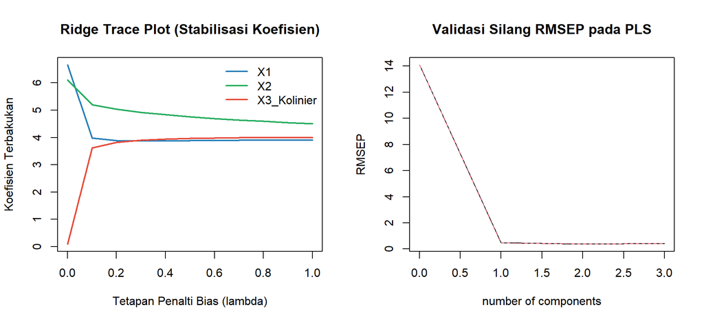

Figure 6.1: Jejak Koefisien Regresi Gulud (Ridge Trace Plot, kiri) yang menstabilkan koefisien saat lambda naik dari 0, serta kurva galat validasi silang RMSEP pada PLS (kanan).

```r
# Visualisasi Ridge Trace Plot & Kurva Validasi RMSEP PLS
par(mfrow = c(1, 2))
matplot(mod_ridge$lambda, t(mod_ridge$coef), type = "l", lwd = 2.2, lty = 1,
        col = c("#2980b9", "#27ae60", "#e74c3c"),
        xlab = "Tetapan Penalti Bias (lambda)", ylab = "Koefisien Terbakukan",
        main = "Ridge Trace Plot (Stabilisasi Koefisien)")
legend("topright", legend = c("X1", "X2", "X3_Kolinier"),
       col = c("#2980b9", "#27ae60", "#e74c3c"), lwd = 2.2, bty = "n")

validationplot(mod_pls, val.type = "RMSEP", main = "Validasi Silang RMSEP pada PLS")
```

```r
par(mfrow = c(1, 1))
```

## 6.5 Cara Membaca Output R & Kesimpulan Kasus

**Kalimat Kesimpulan Siap Kutip:** > *“Pemeriksaan multikolinieritas pada model penuh mendeteksi nilai VIF sangat tinggi pada peubah `X3_Kolinier` ($\text{VIF} = 551,47 > 10$) dan `X1` ($\text{VIF} = 345,03 > 10$). Seleksi peubah metode Stepwise berbasis AIC berhasil mengeliminasi `X3_Kolinier` dan `X4_Noise` sehingga memulihkan model parsimoni terbaik $\hat{Y} = 17,58 + 1,73 X_1 + 2,14 X_2$ ($\text{AIC} = -25,44$; $R^2_{\text{adj}} = 99,97\%$). Apabila seluruh prediktor kolinier tetap dipertahankan, metode Regresi Gulud (Ridge), PCR, dan PLS dengan 2 komponen laten terbukti efektif menstabilkan penduga parameter dan menekan galat prediksi validasi silang hingga $\text{RMSEP} = 0,3804$.”*